# Analysis of English Football Success Stories

## Rohit Sengupta

**Introduction and Background:**

English football is not just a sport; it's a cultural phenomenon, deeply woven into the fabric of the nation. From the bustling streets of London to the serene landscapes of the North, the game resonates with a passion and fervor that few other sports can claim. This is a country where football has been played since medieval times, evolving over centuries from chaotic village games to the structured competitions we see today. The Premier League stands as the pinnacle of this evolution. Although the Premier League was founded in 1992, many clubs which make it and many other leagues up are filled with histories that stretch back over a century. Clubs like Manchester United, Liverpool, and Arsenal are not just names; they represent legacies, memories, and an enduring spirit that has captivated fans globally.

But what truly sets English football apart is its unique blend of tradition and innovation. The terraced houses surrounding stadiums, the age-old rivalries, the songs that have been passed down through generations – all these coexist with cutting-edge stadiums, international fanbases connected through digital mediums, and a cosmopolitan roster of players and managers from every corner of the globe. Football in the UK has always been more than 90 minutes on the pitch. It's about community and identity. It's about the highs of last-minute winners and the lows of heartbreaking relegations. It's about the stories of underdogs defying the odds and giants being toppled. It's an ongoing narrative that shapes weekends and defines moods, with every fan and player penning their own chapter.

The importance of football in England cannot be understated. Not only does it drive the economy with its global viewership and merchandise sales, but it also plays a vital role in the nation's social and cultural landscape. The game has given a voice to communities, provided moments of collective joy and sorrow, and continues to be a source of hope and inspiration for many.

In the chapters that follow, we delve into three distinct narratives from English football, each highlighting a different pathway to success, each emphasizing the unpredictability, charm, and sheer beauty of the beautiful game in the heart of England.

**Brentford's Moneyball Approach**

At its core, Brentford's 'Moneyball' strategy represented a significant shift in how football clubs approached player acquisition and valuation. In a world where clubs often splurged astronomical sums on big-name players, Brentford's reliance on data analytics to identify undervalued talent was both novel and bold. By focusing on metrics that often went unnoticed in traditional scouting, they were able to field a competitive team at a fraction of the cost of their rivals. Their success with this model provided a tangible case study for the efficacy of a data-driven approach in football.

The impact of this strategy has been far-reaching. Not only did it cement Brentford's reputation as an innovative club, but it also spurred a wider appreciation for analytics in football. Clubs across tiers started investing more in data departments, realizing the potential of analytics in leveling the playing field. More info can be learned in this insightful video below: https://www.youtube.com/watch?v=mrwwVoD1RQQ

Analyzing Brentford's journey gives insights into how football clubs can operate efficiently in an increasingly inflated market. Understanding the metrics they prioritized and their decision-making processes can serve as a roadmap for other clubs with limited resources, offering an alternative to the conventional wisdom that financial might is the primary route to success.

**Manchester City's Financial Transformation**

The tale of Manchester City post-2008 is one of rapid ascent, underpinned by unprecedented financial investment. The influx of wealth from the Abu Dhabi United Group transformed a historically underachieving club into one of the world's most dominant footballing forces. Their investment wasn't just limited to acquiring top-tier talent; it extended to revamping infrastructure, scouting networks, and youth development.

City's transformation had a cascading effect on global football. The elevated spending raised the stakes in the Premier League, forcing other clubs to adapt, whether by seeking their own wealthy investors or innovating in other areas. The English top tier became even more competitive, attracting elite talent and amplifying its global appeal. More can be learned here: https://bleacherreport.com/articles/2670212-the-remarkable-story-of-manchester-citys-rise-under-sheikh-mansour

Data analysis of City's transformation provides a deep understanding of how financial muscle, when applied strategically, can expedite success. By analyzing their spending patterns, squad building, and return on investment, one can derive lessons on effective resource allocation and strategic planning in football.

**Leicester City's Fairytale Championship**

The 2015-16 Premier League season stands as a testament to the unpredictable beauty of football. Leicester City's triumph, in the face of 5000-1 odds, was a stunning reminder that passion, teamwork, and tactical nous could still trump financial might. With a squad built on a shoestring budget compared to the league's giants, the Foxes defied logic and expectation.

This underdog story reinvigorated a belief in the magic of football, proving that with the right management, scouting, and team spirit, anything was possible. Clubs and fans worldwide took inspiration, realizing that with astute planning and cohesion, they too could overcome seemingly insurmountable odds. These two videos are definitely my favorites on the matter and provide a view of what it was like: https://www.youtube.com/watch?v=SkfTShRBJ68 https://www.youtube.com/watch?v=gTbxrPQLxEo&t=157s

A data-driven analysis of Leicester's season helps dissect the elements that contributed to their success. From player performance metrics to tactical adjustments, understanding the data behind their championship run offers a blueprint for maximizing output from limited resources. It emphasizes the importance of team dynamics, the value of underrated talent, and the potential outcomes when all the pieces come together harmoniously.

# Data Curation and Parsing

The first task is to curate and find our data through available resources, and import our libraries. We will be using pandas, numpy, requests, matplotlib, BeautifulSoup, and LinearRegression. Next up to acquire our data sources, I was able to find three csv files which provide data on Premier League statistics from 2000-2022, salary and transfer statistics from both the premier league and efl championship. These sources can be accessed here, and they even include data for many other leagues so you are welcome to do your own research on football scenarios around the world!

https://www.kaggle.com/datasets/quadeer15sh/premier-league-standings-11-seasons-20102021 https://github.com/ewenme/transfers/tree/master

```python
import pandas as pd
import numpy as np
import requests
from bs4 import BeautifulSoup
from sklearn.linear_model import LinearRegression
from scipy.stats import linregress
import re
import matplotlib.pyplot as plt
```

First we read in the Premier League Standings data from our csv file using pandas

```python
records = pd.read_csv('EPL Standings 2000-2022.csv')
records
```

|  | Season | Pos | Team | Pld | W | D | L | GF | GA | GD | Pts | Qualification or relegation |
| --- | --- | --- | --- | --- | --- | --- | --- | --- | --- | --- | --- | --- |
| 0 | 2000-01 | 1 | Manchester United | 38 | 24 | 8 | 6 | 79 | 31 | 48 | 80 | Qualification for the Champions League first g... |
| 1 | 2000-01 | 2 | Arsenal | 38 | 20 | 10 | 8 | 63 | 38 | 25 | 70 | Qualification for the Champions League first g... |
| 2 | 2000-01 | 3 | Liverpool | 38 | 20 | 9 | 9 | 71 | 39 | 32 | 69 | Qualification for the Champions League third q... |
| 3 | 2000-01 | 4 | Leeds United | 38 | 20 | 8 | 10 | 64 | 43 | 21 | 68 | Qualification for the UEFA Cup first round[a] |
| 4 | 2000-01 | 5 | Ipswich Town | 38 | 20 | 6 | 12 | 57 | 42 | 15 | 66 | Qualification for the UEFA Cup first round[a] |
| ... | ... | ... | ... | ... | ... | ... | ... | ... | ... | ... | ... | ... |
| 435 | 2021-22 | 16 | Everton | 38 | 11 | 6 | 21 | 43 | 66 | -23 | 39 | Not Applicable |
| 436 | 2021-22 | 17 | Leeds United | 38 | 9 | 11 | 18 | 42 | 79 | -37 | 38 | Not Applicable |
| 437 | 2021-22 | 18 | Burnley | 38 | 7 | 14 | 17 | 34 | 53 | -19 | 35 | Relegation to the EFL Championship |
| 438 | 2021-22 | 19 | Watford | 38 | 6 | 5 | 27 | 34 | 77 | -43 | 23 | Relegation to the EFL Championship |
| 439 | 2021-22 | 20 | Norwich City | 38 | 5 | 7 | 26 | 23 | 84 | -61 | 22 | Relegation to the EFL Championship |

440 rows × 12 columns

We then do the same with our transfer data for the premier league.

```python
transfers_prem = pd.read_csv('premier-league.csv')

transfers_prem
```

|  | club_name | player_name | age | position | club_involved_name | fee | transfer_movement | transfer_period | fee_cleaned | league_name | year | season | country |
| --- | --- | --- | --- | --- | --- | --- | --- | --- | --- | --- | --- | --- | --- |
| 0 | Middlesbrough FC | Tommy Wright | 26.0 | Left Winger | Leicester | €910Th. | in | Summer | 0.91 | Premier League | 1992 | 1992/1993 | England |
| 1 | Middlesbrough FC | Jonathan Gittens | 28.0 | defence | Southampton | €250Th. | in | Summer | 0.25 | Premier League | 1992 | 1992/1993 | England |
| 2 | Middlesbrough FC | Chris Morris | 28.0 | Right-Back | Celtic | ? | in | Summer | NaN | Premier League | 1992 | 1992/1993 | England |
| 3 | Middlesbrough FC | Ben Roberts | 17.0 | Goalkeeper | Boro U18 | - | in | Summer | NaN | Premier League | 1992 | 1992/1993 | England |
| 4 | Middlesbrough FC | Andy Todd | 17.0 | Centre-Back | Boro U18 | - | in | Summer | NaN | Premier League | 1992 | 1992/1993 | England |
| ... | ... | ... | ... | ... | ... | ... | ... | ... | ... | ... | ... | ... | ... |
| 23670 | Wolverhampton Wanderers | Fábio Silva | 20.0 | Centre-Forward | PSV Eindhoven | loan transfer | out | Winter | NaN | Premier League | 2022 | 2022/2023 | England |
| 23671 | Wolverhampton Wanderers | Yerson Mosquera | 21.0 | Centre-Back | Cincinnati | loan transfer | out | Winter | NaN | Premier League | 2022 | 2022/2023 | England |
| 23672 | Wolverhampton Wanderers | Ki-Jana Hoever | 21.0 | Right-Back | Stoke City | loan transfer | out | Winter | NaN | Premier League | 2022 | 2022/2023 | England |
| 23673 | Wolverhampton Wanderers | Gonçalo Guedes | 26.0 | Second Striker | Benfica | loan transfer | out | Winter | NaN | Premier League | 2022 | 2022/2023 | England |
| 23674 | Wolverhampton Wanderers | Matija Sarkic | 25.0 | Goalkeeper | Stoke City | loan transfer | out | Winter | NaN | Premier League | 2022 | 2022/2023 | England |

23675 rows × 13 columns

And then for the EFL

```python
transfers_efl = pd.read_csv('championship.csv')
transfers_efl
```

|  | club_name | player_name | age | position | club_involved_name | fee | transfer_movement | transfer_period | fee_cleaned | league_name | year | season | country |
| --- | --- | --- | --- | --- | --- | --- | --- | --- | --- | --- | --- | --- | --- |
| 0 | Leicester City | David Connolly | 27.0 | attack | West Ham | €750Th. | in | Summer | 0.750 | Championship | 2004 | 2004/2005 | England |
| 1 | Leicester City | Gareth Williams | 22.0 | Central Midfield | Nottm Forest | €750Th. | in | Summer | 0.750 | Championship | 2004 | 2004/2005 | England |
| 2 | Leicester City | Alan Maybury | 25.0 | Right-Back | Heart of Midl. | €75Th. | in | Summer | 0.075 | Championship | 2004 | 2004/2005 | England |
| 3 | Leicester City | Joey Gudjónsson | 24.0 | Central Midfield | Real Betis | free transfer | in | Summer | 0.000 | Championship | 2004 | 2004/2005 | England |
| 4 | Leicester City | Kevin Pressman | 36.0 | Goalkeeper | Sheff Wed | free transfer | in | Summer | 0.000 | Championship | 2004 | 2004/2005 | England |
| ... | ... | ... | ... | ... | ... | ... | ... | ... | ... | ... | ... | ... | ... |
| 24236 | Wigan Athletic | Graeme Shinnie | 31.0 | Defensive Midfield | Aberdeen FC | loan transfer | out | Winter | NaN | Championship | 2022 | 2022/2023 | England |
| 24237 | Wigan Athletic | Josh Stones | 19.0 | Centre-Forward | Ross County | loan transfer | out | Winter | NaN | Championship | 2022 | 2022/2023 | England |
| 24238 | Wigan Athletic | Gwion Edwards | 29.0 | Right Winger | Ross County | loan transfer | out | Winter | NaN | Championship | 2022 | 2022/2023 | England |
| 24239 | Wigan Athletic | Nathan Broadhead | 24.0 | Centre-Forward | Everton U21 | End of loanJan 8, 2023 | out | Winter | NaN | Championship | 2022 | 2022/2023 | England |
| 24240 | Wigan Athletic | Rarmani Edmonds-Green | 23.0 | Centre-Back | Huddersfield | End of loanJan 11, 2023 | out | Winter | NaN | Championship | 2022 | 2022/2023 | England |

24241 rows × 13 columns

Next up we need to perform some webscraping to acquire our data on Brentford's statistics over the last decade to cover the Moneyball era, and overall EFL standings to compare it with. We have chosen to focus on the 2020-2021 season, as this season specifically showcases the culmination of Brentford's success in the Moneyball era, as they were promoted to the Premiere League this season. Our data analysis later on will further show how incredible this was. Our data is scraped from:

https://fbref.com/en/squads/cd051869/history/Brentford-Stats-and-History https://fbref.com/en/comps/10/2020-2021/2020-2021-Championship-Stats#all_results2020-2021101

Our technique is to use a get request on the url as shown, parse it with an html.parser with BeautifulSoup, and then using pd.read_html to read in our table.

```python
res = requests.get('https://fbref.com/en/squads/cd051869/history/Brentford-Stats-and-History')
res2 = requests.get('https://fbref.com/en/comps/10/2020-2021/2020-2021-Championship-Stats#all_results2020-2021101')
soup = BeautifulSoup(res.content, 'html.parser')
soup2 = BeautifulSoup(res2.content, 'html.parser')
tables = pd.read_html(str(soup))
tables2 = pd.read_html(str(soup2))
brentford = tables[0]
efl2021 = tables2[0]
```

Next we want to filter null data which will make our data processing more difficult, by dropping entries which contain these values. Luckily these seasons are irrelevant to our timeline anyways

```python
brentford = brentford.tail(-1)
brentford = brentford.drop(index = {22, 23, 24, 25, 26, 27, 28})
brentford
```

|  | Season | Squad | Country | Comp | LgRank | MP | W | D | L | GF | GA | GD | Pts | Attendance | Top Team Scorer | Goalkeeper | Notes |
| --- | --- | --- | --- | --- | --- | --- | --- | --- | --- | --- | --- | --- | --- | --- | --- | --- | --- |
| 1 | 2022-2023 | Brentford | eng ENG | 1. Premier League | 9th | 38.0 | 15.0 | 14.0 | 9.0 | 58.0 | 46.0 | 12.0 | 59.0 | 17078.0 | Ivan Toney - 20 | David Raya | NaN |
| 2 | 2021-2022 | Brentford | eng ENG | 1. Premier League | 13th | 38.0 | 13.0 | 7.0 | 18.0 | 48.0 | 56.0 | -8.0 | 46.0 | 16918.0 | Ivan Toney - 12 | David Raya | NaN |
| 3 | 2020-2021 | Brentford | eng ENG | 2. Championship | 3rd | 46.0 | 24.0 | 15.0 | 7.0 | 79.0 | 42.0 | 37.0 | 87.0 | 174.0 | Ivan Toney - 31 | David Raya | Promoted, → Semi-finals |
| 4 | 2019-2020 | Brentford | eng ENG | 2. Championship | 3rd | 46.0 | 24.0 | 9.0 | 13.0 | 80.0 | 38.0 | 42.0 | 81.0 | 9156.0 | Ollie Watkins - 25 | David Raya | → Promotion play-offs |
| 5 | 2018-2019 | Brentford | eng ENG | 2. Championship | 11th | 46.0 | 17.0 | 13.0 | 16.0 | 73.0 | 59.0 | 14.0 | 64.0 | 10257.0 | Neal Maupay - 25 | Daniel Bentley | NaN |
| 6 | 2017-2018 | Brentford | eng ENG | 2. Championship | 9th | 46.0 | 18.0 | 15.0 | 13.0 | 62.0 | 52.0 | 10.0 | 69.0 | 10434.0 | Neal Maupay - 12 | Daniel Bentley | NaN |
| 7 | 2016-2017 | Brentford | eng ENG | 2. Championship | 10th | 46.0 | 18.0 | 10.0 | 18.0 | 75.0 | 65.0 | 10.0 | 64.0 | 10467.0 | Lasse Vibe - 15 | Daniel Bentley | NaN |
| 8 | 2015-2016 | Brentford | eng ENG | 2. Championship | 9th | 46.0 | 19.0 | 8.0 | 19.0 | 72.0 | 67.0 | 5.0 | 65.0 | 10310.0 | Lasse Vibe - 14 | David Button | NaN |
| 9 | 2014-2015 | Brentford | eng ENG | 2. Championship | 5th | 46.0 | 23.0 | 9.0 | 14.0 | 78.0 | 59.0 | 19.0 | 78.0 | 10822.0 | Andre Gray - 16 | David Button | → Semi-finals |
| 10 | 2013-2014 | Brentford | eng ENG | 3. League One | 2nd | 46.0 | 28.0 | 10.0 | 8.0 | 72.0 | 43.0 | 29.0 | 94.0 | 7716.0 | Clayton Donaldson - 17 | David Button | Promoted |
| 11 | 2012-2013 | Brentford | eng ENG | 3. League One | 3rd | 46.0 | 21.0 | 16.0 | 9.0 | 62.0 | 47.0 | 15.0 | 79.0 | 6303.0 | Clayton Donaldson - 18 | Simon Moore | → Semi-finals |
| 12 | 2011-2012 | Brentford | eng ENG | 3. League One | 9th | 46.0 | 18.0 | 13.0 | 15.0 | 63.0 | 52.0 | 11.0 | 67.0 | 5643.0 | Gary Alexander - 12 | Richard Lee | NaN |
| 13 | 2010-2011 | Brentford | eng ENG | 3. League One | 11th | 46.0 | 17.0 | 10.0 | 19.0 | 55.0 | 62.0 | -7.0 | 61.0 | 5172.0 | Gary Alexander, Charlie MacDonald - 9 | Richard Lee | NaN |
| 14 | 2009-2010 | Brentford | eng ENG | 3. League One | 9th | 46.0 | 14.0 | 20.0 | 12.0 | 55.0 | 52.0 | 3.0 | 62.0 | 6018.0 | Charlie MacDonald - 15 | Wojciech Szczęsny | NaN |
| 15 | 2008-2009 | Brentford | eng ENG | 4. League Two | 1st | 46.0 | 23.0 | 16.0 | 7.0 | 65.0 | 36.0 | 29.0 | 85.0 | 5700.0 | Charlie MacDonald - 16 | Ben Hamer | Promoted |
| 16 | 2007-2008 | Brentford | eng ENG | 4. League Two | 14th | 46.0 | 17.0 | 8.0 | 21.0 | 52.0 | 70.0 | -18.0 | 59.0 | 4469.0 | Glenn Poole - 14 | Simon Brown | NaN |
| 17 | 2006-2007 | Brentford | eng ENG | 3. League One | 24th | 46.0 | 8.0 | 13.0 | 25.0 | 40.0 | 79.0 | -39.0 | 37.0 | 5600.0 | Jo Kuffour - 12 | Stuart Nelson | Relegated |
| 18 | 2005-2006 | Brentford | eng ENG | 3. League One | 3rd | 46.0 | 20.0 | 16.0 | 10.0 | 72.0 | 52.0 | 20.0 | 76.0 | 6775.0 | Lloyd Owusu - 12 | Stuart Nelson | → Semi-finals |
| 19 | 2004-2005 | Brentford | eng ENG | 3. League One | 4th | 46.0 | 22.0 | 9.0 | 15.0 | 57.0 | 59.0 | -2.0 | 75.0 | 6082.0 | Deon Burton - 10 | Stuart Nelson | → Semi-finals |
| 20 | 2003-2004 | Brentford | eng ENG | 3. Second Division | 17th | 46.0 | 14.0 | 11.0 | 21.0 | 52.0 | 68.0 | -16.0 | 53.0 | 5592.0 | Stephen Hunt - 11 | Paul Smith | NaN |
| 21 | 2002-2003 | Brentford | eng ENG | 3. Second Division | 16th | 46.0 | 14.0 | 12.0 | 20.0 | 47.0 | 56.0 | -9.0 | 54.0 | 5759.0 | Rowan Vine - 10 | Paul Smith | NaN |

```python
efl2021
```

|  | Rk | Squad | MP | W | D | L | GF | GA | GD | Pts | Pts/MP | xG | xGA | xGD | xGD/90 | Attendance | Top Team Scorer | Goalkeeper | Notes |
| --- | --- | --- | --- | --- | --- | --- | --- | --- | --- | --- | --- | --- | --- | --- | --- | --- | --- | --- | --- |
| 0 | 1 | Norwich City | 46 | 29 | 10 | 7 | 75 | 36 | 39 | 97 | 2.11 | 76.9 | 52.0 | 25.0 | 0.54 | 174.0 | Teemu Pukki - 26 | Tim Krul | Promoted |
| 1 | 2 | Watford | 46 | 27 | 10 | 9 | 63 | 30 | 33 | 91 | 1.98 | 66.6 | 45.7 | 20.8 | 0.45 | 172.0 | Ismaila Sarr - 13 | Ben Foster, Daniel Bachmann | Promoted |
| 2 | 3 | Brentford | 46 | 24 | 15 | 7 | 79 | 42 | 37 | 87 | 1.89 | 74.9 | 39.4 | 35.5 | 0.77 | 174.0 | Ivan Toney - 31 | David Raya | Promoted, → Semi-finals |
| 3 | 4 | Swansea City | 46 | 23 | 11 | 12 | 56 | 39 | 17 | 80 | 1.74 | 50.4 | 47.3 | 3.2 | 0.07 | NaN | André Ayew - 16 | Freddie Woodman | → Semi-finals |
| 4 | 5 | Barnsley | 46 | 23 | 9 | 14 | 58 | 50 | 8 | 78 | 1.70 | 58.0 | 47.6 | 10.4 | 0.23 | NaN | Cauley Woodrow - 12 | Jack Walton | → Semi-finals |
| 5 | 6 | Bournemouth | 46 | 22 | 11 | 13 | 73 | 46 | 27 | 77 | 1.67 | 64.4 | 50.0 | 14.4 | 0.31 | 174.0 | Arnaut Danjuma, Dominic Solanke - 15 | Asmir Begović | → Semi-finals |
| 6 | 7 | Reading | 46 | 19 | 13 | 14 | 62 | 54 | 8 | 70 | 1.52 | 55.8 | 47.8 | 8.0 | 0.17 | 87.0 | Lucas João - 19 | Rafael Cabral | NaN |
| 7 | 8 | Cardiff City | 46 | 18 | 14 | 14 | 66 | 49 | 17 | 68 | 1.48 | 58.1 | 54.0 | 4.1 | 0.09 | NaN | Kieffer Moore - 20 | Alex Smithies | NaN |
| 8 | 9 | QPR | 46 | 19 | 11 | 16 | 57 | 55 | 2 | 68 | 1.48 | 61.0 | 62.7 | -1.7 | -0.04 | 174.0 | Lyndon Dykes - 12 | Seny Dieng | NaN |
| 9 | 10 | Middlesbrough | 46 | 18 | 10 | 18 | 55 | 53 | 2 | 64 | 1.39 | 58.2 | 47.2 | 11.0 | 0.24 | 43.0 | Duncan Watmore - 9 | Marcus Bettinelli | NaN |
| 10 | 11 | Millwall | 46 | 15 | 17 | 14 | 47 | 52 | -5 | 62 | 1.35 | 49.6 | 52.8 | -3.1 | -0.07 | 174.0 | Jed Wallace - 11 | Bartosz Białkowski | NaN |
| 11 | 12 | Luton Town | 46 | 17 | 11 | 18 | 41 | 52 | -11 | 62 | 1.35 | 52.8 | 57.0 | -4.2 | -0.09 | 130.0 | James Collins - 10 | Simon Sluga | NaN |
| 12 | 13 | Preston | 46 | 18 | 7 | 21 | 49 | 56 | -7 | 61 | 1.33 | 50.6 | 60.8 | -10.2 | -0.22 | NaN | Scott Sinclair - 9 | Daniel Iversen | NaN |
| 13 | 14 | Stoke City | 46 | 15 | 15 | 16 | 50 | 52 | -2 | 60 | 1.30 | 50.2 | 44.8 | 5.4 | 0.12 | NaN | Nick Powell - 12 | Adam Davies | NaN |
| 14 | 15 | Blackburn | 46 | 15 | 12 | 19 | 65 | 54 | 11 | 57 | 1.24 | 68.9 | 52.4 | 16.5 | 0.36 | NaN | Adam Armstrong - 28 | Thomas Kaminski | NaN |
| 15 | 16 | Coventry City | 46 | 14 | 13 | 19 | 49 | 61 | -12 | 55 | 1.20 | 48.7 | 62.0 | -13.4 | -0.29 | NaN | Tyler Walker - 7 | Ben Wilson | NaN |
| 16 | 17 | Nott'ham Forest | 46 | 12 | 16 | 18 | 37 | 45 | -8 | 52 | 1.13 | 49.8 | 52.2 | -2.4 | -0.05 | NaN | Lewis Grabban - 6 | Brice Samba | NaN |
| 17 | 18 | Birmingham City | 46 | 13 | 13 | 20 | 37 | 61 | -24 | 52 | 1.13 | 45.6 | 61.0 | -15.5 | -0.34 | NaN | Lukas Jutkiewicz - 8 | Neil Etheridge | NaN |
| 18 | 19 | Bristol City | 46 | 15 | 6 | 25 | 46 | 68 | -22 | 51 | 1.11 | 39.8 | 71.2 | -31.4 | -0.68 | NaN | Nahki Wells - 10 | Daniel Bentley | NaN |
| 19 | 20 | Huddersfield | 46 | 12 | 13 | 21 | 50 | 71 | -21 | 49 | 1.07 | 46.0 | 68.4 | -22.3 | -0.49 | NaN | Josh Koroma - 8 | Ryan Schofield | NaN |
| 20 | 21 | Derby County | 46 | 11 | 11 | 24 | 36 | 58 | -22 | 44 | 0.96 | 47.4 | 54.3 | -6.9 | -0.15 | NaN | Colin Kazim-Richards - 8 | David Marshall | NaN |
| 21 | 22 | Wycombe | 46 | 11 | 10 | 25 | 39 | 69 | -30 | 43 | 0.93 | 47.2 | 74.2 | -27.0 | -0.59 | 87.0 | Uche Ikpeazu - 6 | Ryan Allsop | Relegated |
| 22 | 23 | Rotherham Utd | 46 | 11 | 9 | 26 | 44 | 60 | -16 | 42 | 0.91 | 57.2 | 62.0 | -4.7 | -0.10 | NaN | Michael Smith - 10 | Jamal Blackman | Relegated |
| 23 | 24 | Sheffield Weds | 46 | 12 | 11 | 23 | 40 | 61 | -21 | 41 | 0.89 | 48.2 | 59.5 | -11.4 | -0.25 | NaN | Josh Windass - 9 | Keiren Westwood | 6-point deduction 1, Relegated |

In this section, we aim to visualize the Premier League standings over a span of 22 years, specifically highlighting two noteworthy events: Manchester City's performance surge post their buyout by the Abu Dhabi United Group and Leicester City's astonishing title win in 2015-16.

To make our plot more readable and focused, we've shortlisted seven prominent Premier League teams, commonly referred to as the 'Big 6', plus the inclusion of Leicester City due to their significant achievement in the period under review.

```python
desired_teams = ['Arsenal', 'Manchester United', 'Liverpool', 'Chelsea',
                 'Tottenham Hotspur', 'Manchester City', 'Leicester City']
```

We then filter our dataset to retain only the records of these selected teams.

We proceed to create a line plot, where each team's performance over the years is represented by a distinct line, depicting their total points earned each season.

Two crucial points on our plot are annotated:

The 2007-08 season indicates when Manchester City was acquired by the Abu Dhabi United Group. This is annotated near Manchester City's performance for that year to provide context for the team's subsequent rise. The 2015-16 season is annotated to spotlight Leicester City's remarkable achievement when they secured the Premier League title against all odds.

Finally, we display our line plot using plt.show().

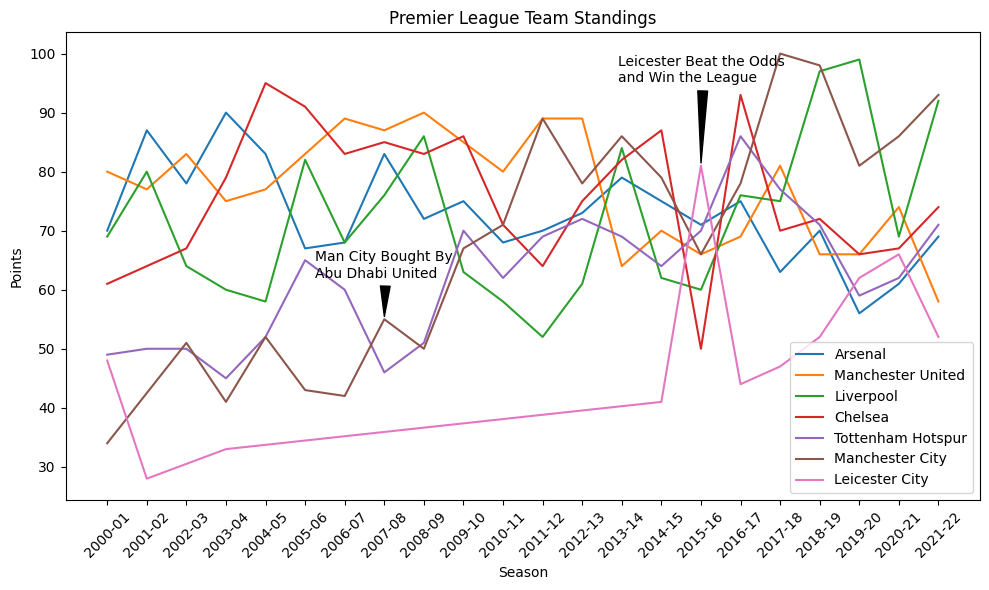

```python
# Filter the records DataFrame for the desired teams
filtered_records = records[records['Team'].isin(desired_teams)]

# Create a line plot for each desired team
plt.figure(figsize=(10, 6))

for team in desired_teams:
    team_data = filtered_records[filtered_records['Team'] == team]
    plt.plot(team_data['Season'], team_data['Pts'], label=team)

plt.annotate('Man City Bought By \nAbu Dhabi United', xy=('2007-08', 55),xytext=(-50, 30), textcoords='offset points',
                 arrowprops=dict(facecolor='black', arrowstyle='wedge,tail_width=0.7', lw=1))
plt.annotate('Leicester Beat the Odds \nand Win the League', xy=('2015-16', 81),xytext=(-60, 60), textcoords='offset points',
                 arrowprops=dict(facecolor='black', arrowstyle='wedge,tail_width=0.7', lw=1))

plt.xlabel('Season')
plt.ylabel('Points')
plt.title('Premier League Team Standings')
plt.legend()
plt.xticks(rotation=45)
plt.tight_layout()

plt.show()
```

In this section, we focus on the journey of Brentford F.C., a club that has seen its fair share of ups and downs in English football. We aim to visualize their season-by-season performance, drawing attention to significant events in their journey.

We reverse the order of the Brentford data so that the seasons are in chronological order for our line plot.

Using a line plot, we chart Brentford's performance across different seasons. Each season's point tally is plotted, and the line is distinctly colored in red for clear visibility.

To offer context on Brentford's journey, four major milestones are annotated:

2006-2007: Their relegation to League Two. 2008-2009: Their bounce back with promotion to League One. 2013-2014: A significant achievement when they moved up to the Championship. 2020-2021: Their ascent to the top flight of English football, the Premier League. These annotations are strategically placed near the data points they represent, connected with arrows for clarity.

Through this visualization, viewers can quickly grasp Brentford's tumultuous journey and appreciate the milestones that define their story in the English football landscape.

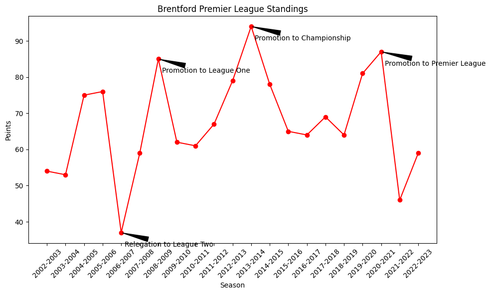

```python
brentford = brentford.iloc[::-1]
# Create a line plot for Brentford with a red line
plt.figure(figsize=(10, 6))
plt.plot(brentford['Season'], brentford['Pts'], marker='o', color='red')

# Annotate points with arrows and text
annotations = [
    ('2006-2007', 'Relegation to League Two'),
    ('2008-2009', 'Promotion to League One'),
    ('2013-2014', 'Promotion to Championship'),
    ('2020-2021', 'Promotion to Premier League')
]

for season, text in annotations:
    point = brentford[brentford['Season'] == season]
    plt.annotate(text, xy=(season, point['Pts']), xytext=(5, -20), textcoords='offset points',
                 arrowprops=dict(facecolor='black', arrowstyle='wedge,tail_width=0.7', lw=1))

plt.xlabel('Season')
plt.ylabel('Points')
plt.title('Brentford Premier League Standings')
plt.xticks(rotation=45)
plt.tight_layout()

plt.show()
```

In this tutorial section, we delve into cleaning and preparing our dataset related to transfer activities in the English Football League (EFL) between 2012 and 2021. Proper data cleaning is essential for accurate analysis, especially when dealing with monetary values, which often come in various formats.

First, we ensure that the 'year' column values are numerical. This is crucial for filtering data in subsequent steps.

We then filter our dataset to consider only the records within the relevant timeframe, i.e., from 2012 to the end of 2020.

Transfer fees in football can be complex, with values sometimes being undisclosed, loans, or free transfers. We address these intricacies by:

Converting all fees to strings. Defining a list of non-numeric values that need replacement. Cleaning the fee column by setting non-numeric values to zero.

The data might have transfer fees represented in various ways, such as millions (e.g., "€2.5m") or thousands (e.g., "€500Th."). We need to convert these values into a consistent numerical format for effective analysis.

Using regular expressions, we recognize these patterns and perform the necessary conversions.

By the end of this process, we have a clean, consistent dataset with transfer records from 2012 to 2020, with all transfer fees in a standardized numerical format, ready for any downstream analysis.

```python
transfers_efl['year'] = pd.to_numeric(transfers_efl['year'], errors='coerce')

# Filter rows within the relevant timeframe (2012 to 2021)
transfers_efl = transfers_efl[(transfers_efl['year'] >= 2012) & (transfers_efl['year'] < 2021)]

transfers_efl['fee'] = transfers_efl['fee'].astype(str)

# Replace non-numeric values with zeros
non_numeric_values = ['?', '-', 'loan transfer', 'free transfer']

def clean_fee(value):
    if value in non_numeric_values or re.match(r'^End of loan', value):
        return 0
    return value

transfers_efl['fee'] = transfers_efl['fee'].apply(clean_fee)

# Convert monetary values to numerical form
def convert_monetary_value(value):
    if isinstance(value, str) and re.match(r'^€', value):
        if re.match(r'^€\d+\.\d+m$', value):
            return int(float(value[1:-1]) * 1000000)
        elif re.match(r'^€\d+Th\.$', value):
            return int(float(value[1:-3]) * 1000)
    if isinstance(value, str) and re.match(r'^Loan fee:€', value):
        if re.match(r'^Loan fee:€\d+\.\d+m$', value):
            return int(float(value[10:-1]) * 1000000)
        elif re.match(r'^Loan fee:€\d+Th\.$', value):
            return int(float(value[10:-3]) * 1000)
    return value

transfers_efl['fee'] = transfers_efl['fee'].apply(convert_monetary_value)
```

Our dataframe has a column dictating whether the transfer was incoming or outgoing. If we want to do an analysis of net spending, it would be helpful to have a column dedicated towards negative versus positive value. So we do that here.

```python
transfers_efl['net_val'] = transfers_efl.apply(lambda row: -1 * row['fee'] if row['transfer_movement'] == 'in' else row['fee'], axis=1)
```

In this section, we're working on summarizing the transfer activities of football clubs, focusing on how much they've spent on buying players ("in" transfers) and how much they've earned from selling players ("out" transfers) for each year.

We create a custom aggregation function sum_fees to sum up the transfer fees. This function goes through each value, ensures it's a valid number, and then sums them up.

Using groupby, we categorize the data by club_name, year, and transfer_movement (which typically contains values like "in" for transfers into a club and "out" for transfers out of a club). The transfer fees within each category are then summed using our sum_fees function. The result is then unstacked, turning the 'transfer_movement' categories into separate columns for easier analysis.

For clarity, we rename the columns to more descriptive names. Instead of 'in' and 'out', they are renamed to 'value_spent' (indicating the value spent on buying players) and 'total_sold' (indicating the total earnings from player sales).

We calculate the net value (profit or loss) for each club per year by subtracting the value spent from the total value earned from sales.

Finally, we reset the dataframe's index. This makes club_name and year regular columns instead of being part of the multi-level index. It makes the dataframe easier to work with for subsequent analyses or visualizations.

```python
def sum_fees(values):
    return sum(int(value) for value in values if pd.notna(value) and str(value).isdigit())

summary_df = transfers_efl.groupby(['club_name', 'year', 'transfer_movement'])['fee'].apply(sum_fees).unstack(fill_value=0)


# Rename columns for clarity
summary_df.rename(columns={'in': 'value_spent', 'out': 'total_sold'}, inplace=True)

summary_df['net_value'] = summary_df['total_sold'] - summary_df['value_spent']

# Reset the index to get club_name and year as columns
summary_df.reset_index(inplace=True)
```

This section visualizes three financial aspects for a selection of football clubs:

The total value they spent on transfers The total they earned from player sales Their net value (profit/loss) for each year. Here's a summarized description of what's happening:

We calculate the average for each financial aspect (value spent, value sold, and net value) for all clubs in each year. This will give us an overall trend in the transfer market.

Plotting Total Spent by Year: The total amount each selected club has spent on new player acquisitions each year is visualized. We also plot a dashed linear regression line representing the average value spent across all clubs, to provide a benchmark.

Plotting Total Sold by Year: Similarly, we visualize the total amount each selected club earned from selling their players. Again, a dashed line represents the average earnings from player sales across all clubs.

Plotting Net Value by Year: This plot represents the net financial performance for each selected club, i.e., the difference between what they earned from player sales and what they spent. The average net value across all clubs is also shown.

In all the plots, specific teams are chosen to be visualized using the teams_to_plot list Similar to our earlier plots, this helps to make the graph easier to read and analyze, and focuses on the main teams. These line plots, accompanied by an average trend (the dashed line), provide a clear insight into each club's financial activity in the transfer market compared to the average trend across clubs.

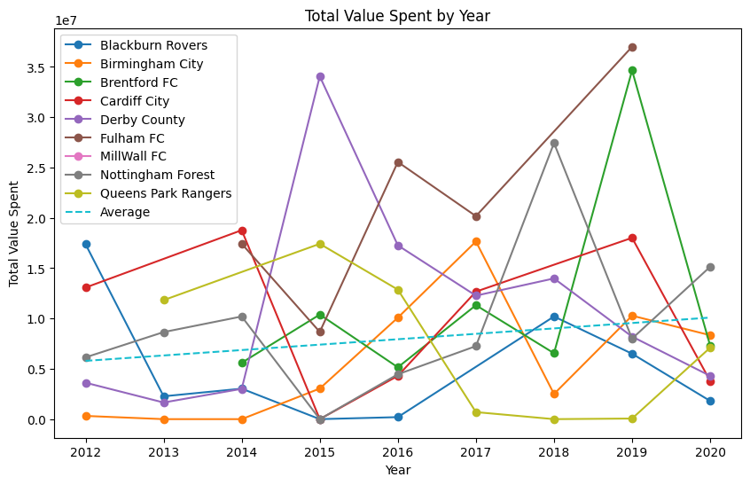

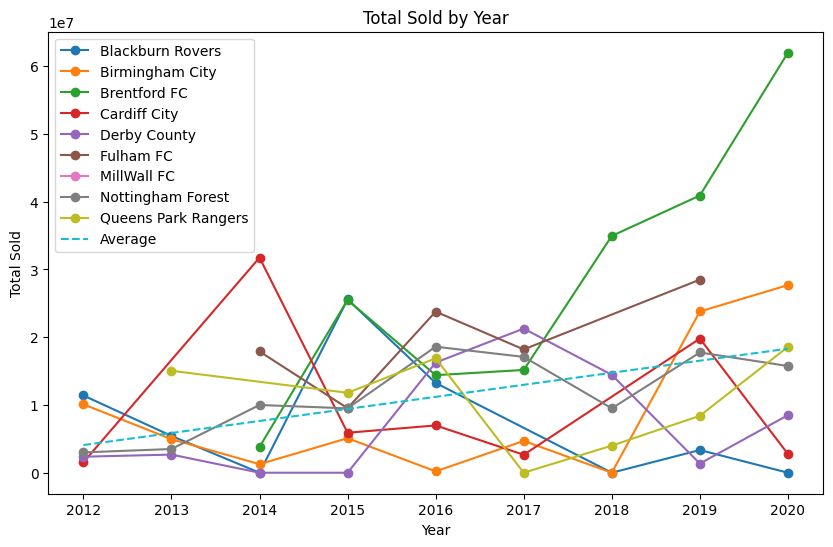

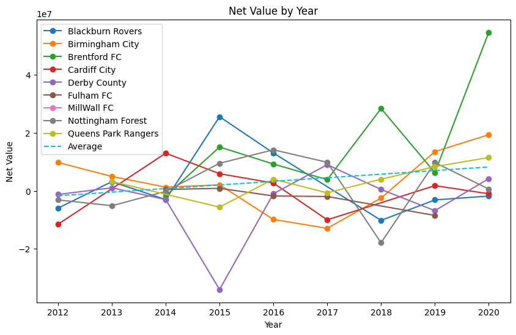

```python
# Calculate average for each year
average_df = summary_df.set_index('club_name').groupby('year').mean()

teams_to_plot = ['Blackburn Rovers', 'Birmingham City', 'Brentford FC', 'Cardiff City', 'Derby County', 'Fulham FC', 'MillWall FC', 'Nottingham Forest', 'Queens Park Rangers']

# Plot total value spent
plt.figure(figsize=(10, 6))
for team in teams_to_plot:
    team_data = summary_df[summary_df['club_name'] == team]
    plt.plot(team_data['year'], team_data['value_spent'], marker='o', label=team)

# Add linear regression line for the average
reg = LinearRegression().fit(average_df.index.values.reshape(-1, 1), average_df['value_spent'])
plt.plot(average_df.index, reg.predict(average_df.index.values.reshape(-1, 1)), linestyle='dashed', label='Average')

plt.xlabel('Year')
plt.ylabel('Total Value Spent')
plt.title('Total Value Spent by Year')
plt.legend()
plt.show()

# Plot total sold
plt.figure(figsize=(10, 6))
for team in teams_to_plot:
    team_data = summary_df[summary_df['club_name'] == team]
    plt.plot(team_data['year'], team_data['total_sold'], marker='o', label=team)

# Add linear regression line for the average
reg = LinearRegression().fit(average_df.index.values.reshape(-1, 1), average_df['total_sold'])
plt.plot(average_df.index, reg.predict(average_df.index.values.reshape(-1, 1)), linestyle='dashed', label='Average')

plt.xlabel('Year')
plt.ylabel('Total Sold')
plt.title('Total Sold by Year')
plt.legend()
plt.show()

# Plot net value
plt.figure(figsize=(10, 6))
for team in teams_to_plot:
    team_data = summary_df[summary_df['club_name'] == team]
    plt.plot(team_data['year'], team_data['net_value'], marker='o', label=team)

# Add linear regression line for the average
reg = LinearRegression().fit(average_df.index.values.reshape(-1, 1), average_df['net_value'])
plt.plot(average_df.index, reg.predict(average_df.index.values.reshape(-1, 1)), linestyle='dashed', label='Average')

plt.xlabel('Year')
plt.ylabel('Net Value')
plt.title('Net Value by Year')
plt.legend()
plt.show()
```

In this visualization, we are focusing on the transfer market financial activity of Brentford FC, a club known for its Moneyball-inspired recruitment strategy.

Here's a brief explanation of what this code achieves:

We begin by isolating the data for Brentford FC alone.

A side-by-side bar graph is a fantastic way to juxtapose two related data sets for the same set of categories. In this case, the categories are years, and the two data sets are the total value Brentford spent on acquiring players and the total revenue they made from selling players.

The graph allows for an immediate comparison for each year:

On the left of each year's pair of bars, we see the total value Brentford FC spent on new player acquisitions (Total Value Spent). On the right, slightly faded for contrast, we see how much they earned from selling their own players (Total Sold). With this visualization, a viewer can immediately discern Brentford FC's financial activity in the transfer market year by year. It's particularly insightful to understand how much they spent versus how much they earned back, reflecting the effectiveness of their recruitment strategy.

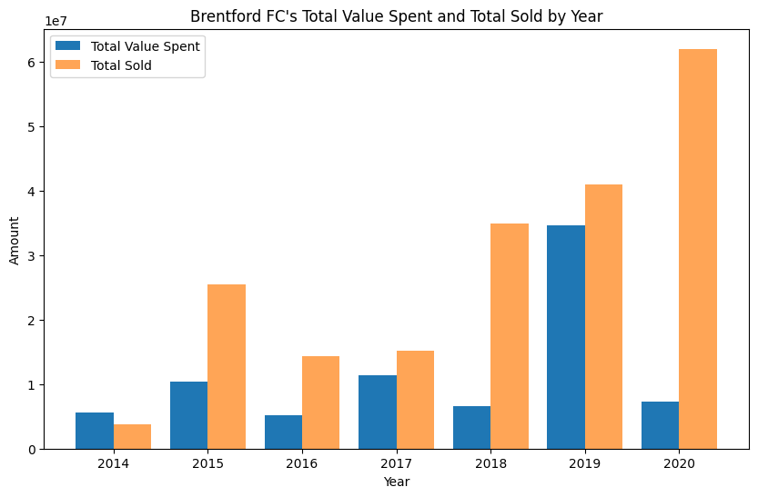

```python
brentford_data = summary_df[summary_df['club_name'] == 'Brentford FC']

# Create a bar graph with side-by-side bars
bar_width = 0.4
index = np.arange(len(brentford_data['year']))

plt.figure(figsize=(10, 6))
plt.bar(index, brentford_data['value_spent'], width=bar_width, label='Total Value Spent')
plt.bar(index + bar_width, brentford_data['total_sold'], width=bar_width, label='Total Sold', alpha=0.7)

plt.xlabel('Year')
plt.ylabel('Amount')
plt.title("Brentford FC's Total Value Spent and Total Sold by Year")
plt.xticks(index + bar_width/2, brentford_data['year'])
plt.legend()
plt.show()
```

In this visualization, the aim is to showcase Brentford FC's efficiency in terms of how their spending translates to on-field performance. Specifically, we are measuring how many points (and goal difference) they obtain for every million pounds they spend.

Data Selection: We isolate Brentford FC's summary data from the main DataFrame. Furthermore, we consider only specific rows from Brentford's performance data. We compute spending efficiency as the ratio of points earned to every million pounds spent. Similarly, we calculate an efficiency ratio for their goal difference.

Graph Creation: We plot two lines on a single graph:

This visualization allows viewers to assess Brentford FC's financial efficiency on two key performance metrics: total points obtained and goal difference. If the lines trend upward over time, it suggests that Brentford's recruitment strategy is increasingly effective, as they get more on-field value for every pound they spend.

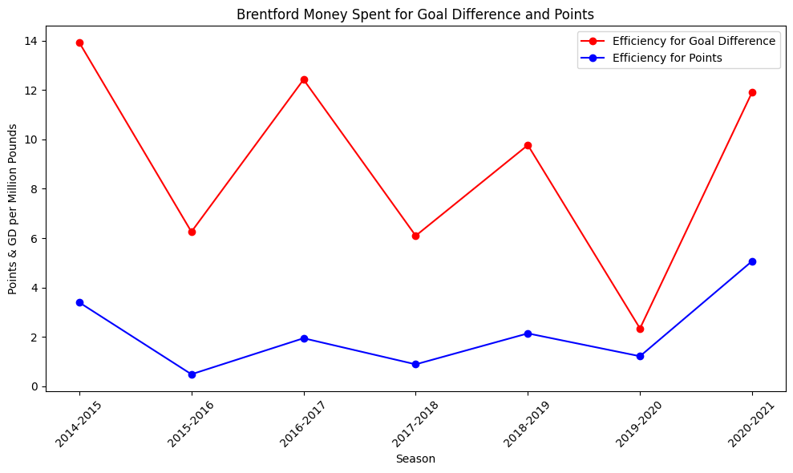

```python
summary_brent = summary_df[summary_df['club_name'] == 'Brentford FC']

brentford_new = brentford.loc[[3,4,5,6,7,8,9]].iloc[::-1]
brentford_new['spending_efficiency'] = brentford_new['Pts'] / (summary_brent['value_spent']/1000000).values


plt.figure(figsize=(10, 6))
plt.plot(brentford_new['Season'], brentford_new['spending_efficiency'], marker='o', color='red')
plt.plot(brentford_new['Season'], brentford_new['GD']/(summary_brent['value_spent']/1000000).values, marker = 'o', color = 'blue')


plt.xlabel('Season')
plt.ylabel('Points & GD per Million Pounds')
plt.title('Brentford Money Spent for Goal Difference and Points')
plt.legend({'Efficiency for Points', 'Efficiency for Goal Difference'})
plt.xticks(rotation=45)
plt.tight_layout()

plt.show()
```

Data Cleanup and Transformation: Filtering the summary_df for records from the year 2020. Removing clubs that did not spend any money. Renaming certain club names, in order to match the format displayed in our efl dataframe

The merged_df DataFrame is created by merging the provided efl2021 DataFrame with the transformed summary_2020 DataFrame on club names.

Visualization: The scatter plot represents the 'Value Spent' on the x-axis and the points clubs have accumulated ('Pts') on the y-axis. Each dot represents a club. The club names are used as annotations for each point.

In essence, this visualization aims to determine if there's a visible correlation between spending on players and on-field success (measured by points) for the clubs in the 2021 season of the English Football League. If a positive correlation exists, clubs that spent more would generally have earned more points. Conversely, a lack of clear correlation might indicate that on-field success is not solely reliant on transfer spendings.

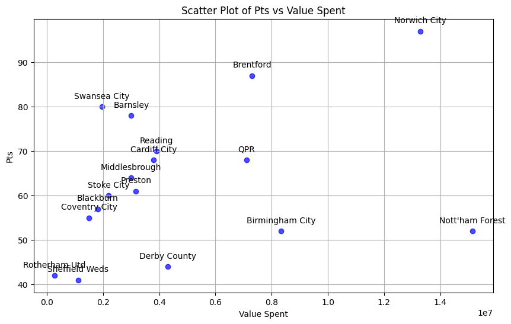

```python
summary_2020 = summary_df[summary_df['year'] == 2020]
summary_2020 = summary_2020[summary_2020['value_spent'] != 0]
summary_2020['club_name'] = summary_2020['club_name'].str.replace(' FC', '')
summary_2020['club_name'] = summary_2020['club_name'].str.replace('Queens Park Rangers', 'QPR')
summary_2020['club_name'] = summary_2020['club_name'].str.replace('United', 'Utd')
summary_2020['club_name'] = summary_2020['club_name'].str.replace('Nottingham Forest', 'Nott\'ham Forest')
summary_2020['club_name'] = summary_2020['club_name'].str.replace('Preston North End', 'Preston')
summary_2020['club_name'] = summary_2020['club_name'].str.replace('Sheffield Wednesday', 'Sheffield Weds')
summary_2020['club_name'] = summary_2020['club_name'].str.replace('Blackburn Rovers', 'Blackburn')

# Merge DataFrames based on club names
merged_df = pd.merge(efl2021, summary_2020, left_on='Squad', right_on='club_name', how='left')

# Create a scatter plot
plt.figure(figsize=(10, 6))
plt.scatter(merged_df['value_spent'], merged_df['Pts'], color='b', alpha=0.7)

# Annotate points with team names
for i, row in merged_df.iterrows():
    plt.annotate(row['Squad'], (row['value_spent'], row['Pts']), textcoords="offset points", xytext=(0,10), ha='center')


plt.xlabel('Value Spent')
plt.ylabel('Pts')
plt.title('Scatter Plot of Pts vs Value Spent')
plt.grid(True)
plt.show()
```

Now that we have seen an analysis of how impactful Brentford's tactics were in their success and ascension to the Premier League, let's take a look at our other two stories involving Manchester City and Leicester. First off we filter our dataframe to only correspond with relevant years, starting with 2007 the year before Manchester City was acquired. Luckily we already have our necessary functions to format our money fees properly, so we can just pass in our dataframe

```python
transfers_prem['year'] = pd.to_numeric(transfers_prem['year'], errors='coerce')
transfers_prem = transfers_prem[(transfers_prem['year'] >= 2007) & (transfers_prem['year'] < 2021)]

transfers_prem['fee'] = transfers_prem['fee'].astype(str)

# Replace non-numeric values with zeros
transfers_prem['fee'] = transfers_prem['fee'].apply(clean_fee)

# Convert monetary values to numerical form
transfers_prem['fee'] = transfers_prem['fee'].apply(convert_monetary_value)
```

We perform a similar procedure as we have already done with our analysis of Brentford

```python
summary_prem = transfers_prem.groupby(['club_name', 'year', 'transfer_movement'])['fee'].apply(sum_fees).unstack(fill_value=0)


# Rename columns for clarity
summary_prem.rename(columns={'in': 'value_spent', 'out': 'total_sold'}, inplace=True)

summary_prem['net_value'] = summary_prem['total_sold'] - summary_prem['value_spent']

# Reset the index to get club_name and year as columns
summary_prem.reset_index(inplace=True)
```

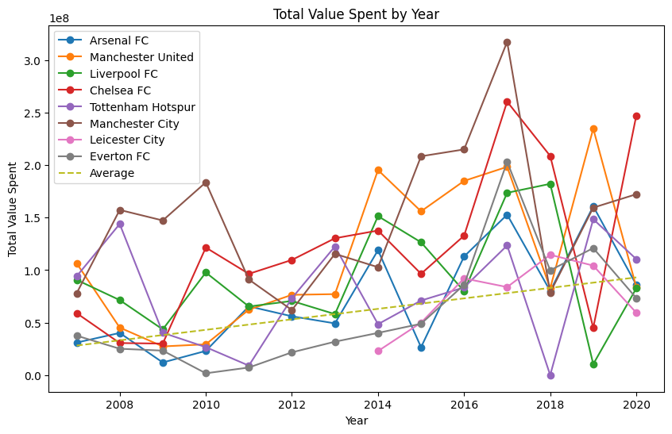

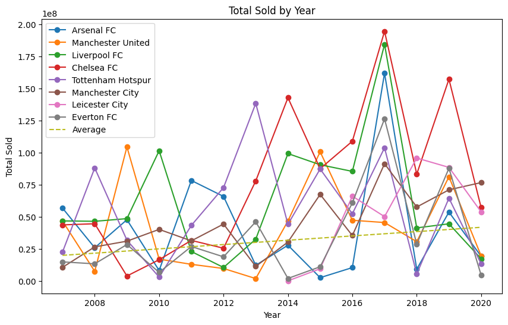

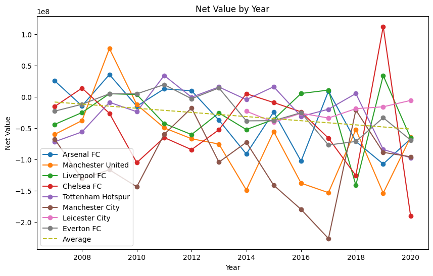

```python
# Calculate average for each year
average_prem = summary_prem.set_index('club_name').groupby('year').mean()

teams_to_plot = ['Arsenal FC', 'Manchester United', 'Liverpool FC', 'Chelsea FC',
                 'Tottenham Hotspur', 'Manchester City', 'Leicester City', 'Everton FC']

# Plot total value spent
plt.figure(figsize=(10, 6))
for team in teams_to_plot:
    team_data = summary_prem[summary_prem['club_name'] == team]
    plt.plot(team_data['year'], team_data['value_spent'], marker='o', label=team)

# Add linear regression line for the average
reg = LinearRegression().fit(average_prem.index.values.reshape(-1, 1), average_prem['value_spent'])
plt.plot(average_prem.index, reg.predict(average_prem.index.values.reshape(-1, 1)), linestyle='dashed', label='Average')

plt.xlabel('Year')
plt.ylabel('Total Value Spent')
plt.title('Total Value Spent by Year')
plt.legend()
plt.show()

# Plot total sold
plt.figure(figsize=(10, 6))
for team in teams_to_plot:
    team_data = summary_prem[summary_prem['club_name'] == team]
    plt.plot(team_data['year'], team_data['total_sold'], marker='o', label=team)

# Add linear regression line for the average
reg = LinearRegression().fit(average_prem.index.values.reshape(-1, 1), average_prem['total_sold'])
plt.plot(average_prem.index, reg.predict(average_prem.index.values.reshape(-1, 1)), linestyle='dashed', label='Average')

plt.xlabel('Year')
plt.ylabel('Total Sold')
plt.title('Total Sold by Year')
plt.legend()
plt.show()

# Plot net value
plt.figure(figsize=(10, 6))
for team in teams_to_plot:
    team_data = summary_prem[summary_prem['club_name'] == team]
    plt.plot(team_data['year'], team_data['net_value'], marker='o', label=team)

# Add linear regression line for the average
reg = LinearRegression().fit(average_prem.index.values.reshape(-1, 1), average_prem['net_value'])
plt.plot(average_prem.index, reg.predict(average_prem.index.values.reshape(-1, 1)), linestyle='dashed', label='Average')

plt.xlabel('Year')
plt.ylabel('Net Value')
plt.title('Net Value by Year')
plt.legend()
plt.show()
```

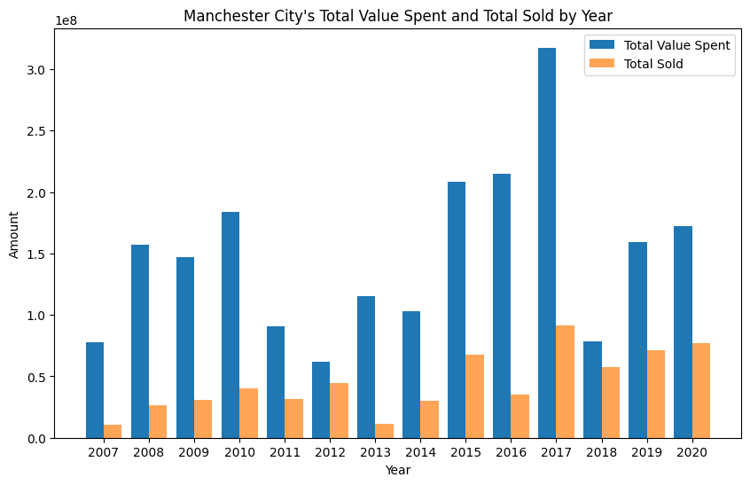

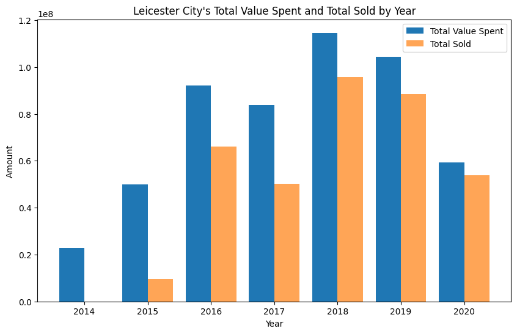

```python
mc_data = summary_prem[summary_prem['club_name'] == 'Manchester City']


# Create a bar graph with side-by-side bars
bar_width = 0.4
index = np.arange(len(mc_data['year']))

plt.figure(figsize=(10, 6))
plt.bar(index, mc_data['value_spent'], width=bar_width, label='Total Value Spent')
plt.bar(index + bar_width, mc_data['total_sold'], width=bar_width, label='Total Sold', alpha=0.7)

plt.xlabel('Year')
plt.ylabel('Amount')
plt.title("Manchester City's Total Value Spent and Total Sold by Year")
plt.xticks(index + bar_width/2, mc_data['year'])
plt.legend()
plt.show()

lc_data = summary_prem[summary_prem['club_name'] == 'Leicester City']


# Create a bar graph with side-by-side bars
bar_width = 0.4
index = np.arange(len(lc_data['year']))

plt.figure(figsize=(10, 6))
plt.bar(index, lc_data['value_spent'], width=bar_width, label='Total Value Spent')
plt.bar(index + bar_width, lc_data['total_sold'], width=bar_width, label='Total Sold', alpha=0.7)

plt.xlabel('Year')
plt.ylabel('Amount')
plt.title("Leicester City's Total Value Spent and Total Sold by Year")
plt.xticks(index + bar_width/2, lc_data['year'])

plt.legend()
plt.show()
```

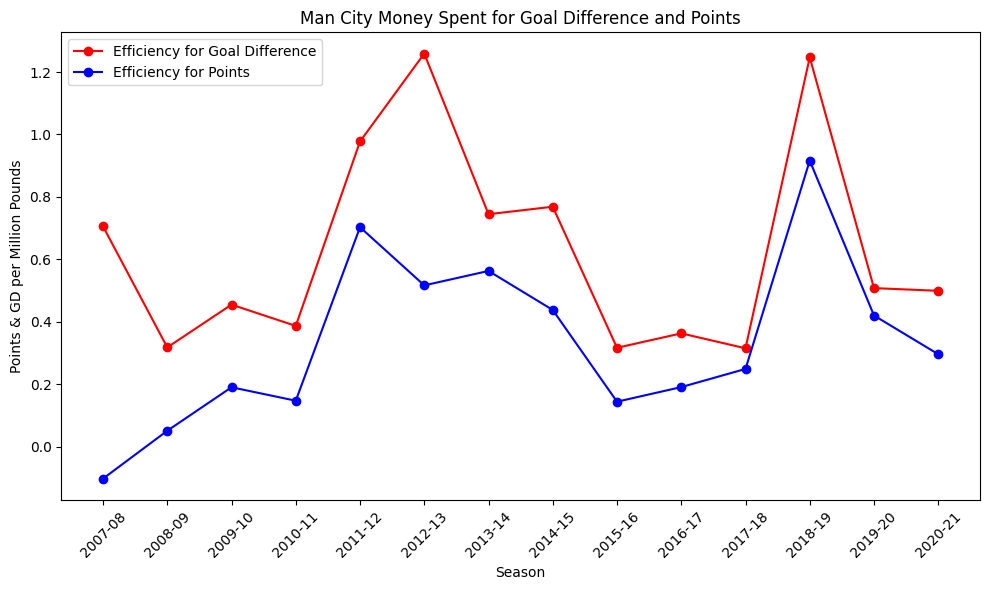

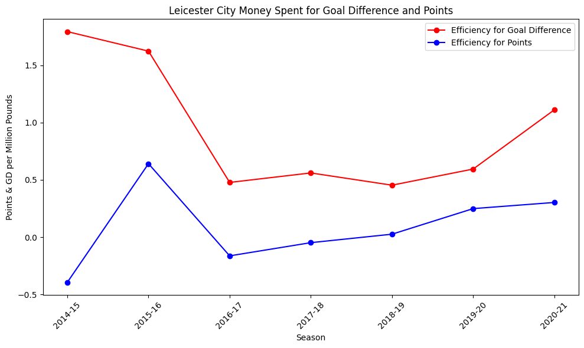

```python
summary_mc = summary_prem[summary_prem['club_name'] == 'Manchester City']
mancity = records[records['Team'] == 'Manchester City']
mancity = mancity.loc[148:400]

summary_lc = summary_prem[summary_prem['club_name'] == 'Leicester City']
leicester = records[records['Team'] == 'Leicester City']
leicester = leicester.loc[293:404]

summary_mc['spending_efficiency'] = mancity['Pts'].values / (summary_mc['value_spent']/1000000).values
summary_lc['spending_efficiency'] = leicester['Pts'].values / (summary_lc['value_spent']/1000000).values



plt.figure(figsize=(10, 6))
plt.plot(mancity['Season'], summary_mc['spending_efficiency'], marker='o', color='red')
plt.plot(mancity['Season'], mancity['GD']/(summary_mc['value_spent']/1000000).values, marker = 'o', color = 'blue')


plt.xlabel('Season')
plt.ylabel('Points & GD per Million Pounds')
plt.title('Man City Money Spent for Goal Difference and Points')
plt.legend({'Efficiency for Points', 'Efficiency for Goal Difference'})
plt.xticks(rotation=45)
plt.tight_layout()

plt.show()


plt.figure(figsize=(10, 6))
plt.plot(leicester['Season'], summary_lc['spending_efficiency'], marker='o', color='red')
plt.plot(leicester['Season'], leicester['GD']/(summary_lc['value_spent']/1000000).values, marker = 'o', color = 'blue')


plt.xlabel('Season')
plt.ylabel('Points & GD per Million Pounds')
plt.title('Leicester City Money Spent for Goal Difference and Points')
plt.legend({'Efficiency for Points', 'Efficiency for Goal Difference'})
plt.xticks(rotation=45)
plt.tight_layout()

plt.show()
```

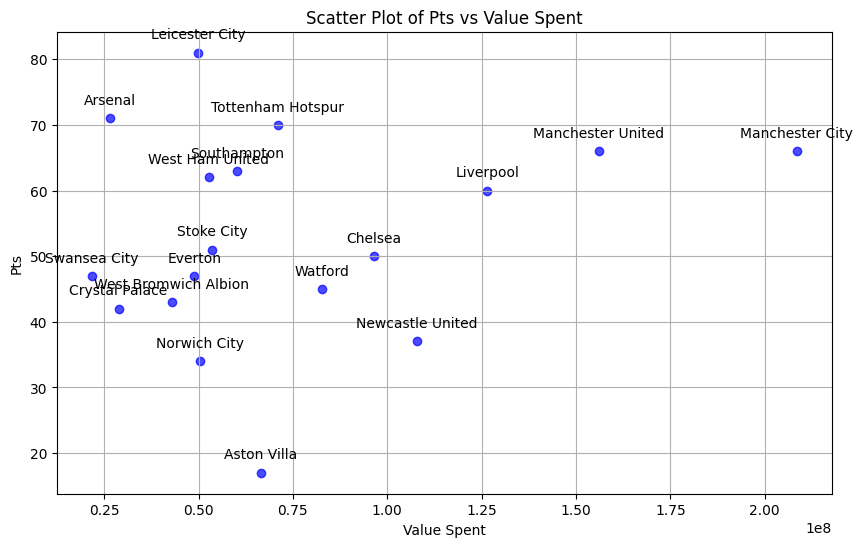

```python
summary_2015 = summary_prem[summary_prem['year'] == 2015]
summary_2015 = summary_2015[summary_2015['value_spent'] != 0]
records_filtered = records[records['Season'] == '2015-16']

summary_2015['club_name'] = summary_2015['club_name'].str.replace(' FC', '')

# Merge DataFrames based on club names
merged_df = pd.merge(records_filtered, summary_2015, left_on='Team', right_on='club_name', how='left')

# Create a scatter plot
plt.figure(figsize=(10, 6))
plt.scatter(merged_df['value_spent'], merged_df['Pts'], color='b', alpha=0.7)

# Annotate points with team names
for i, row in merged_df.iterrows():
    plt.annotate(row['Team'], (row['value_spent'], row['Pts']), textcoords="offset points", xytext=(0,10), ha='center')


plt.xlabel('Value Spent')
plt.ylabel('Pts')
plt.title('Scatter Plot of Pts vs Value Spent')
plt.grid(True)
plt.show()
```

**Brentford's Efficiency in Comparison with Leicester and Man City: An Analysis**

In the high-stakes world of football, the strategic investment in players often plays a critical role in a team's performance and success. Historically, clubs with deeper pockets like Manchester City have been able to acquire top talent, altering the trajectory of their performance in leagues. Similarly, teams like Leicester City have also shown remarkable progress, with their iconic 2015-2016 Premier League title run acting as a testimony to efficient investment and team management.

In our analysis, we dive into the intriguing case of Brentford, a club that has steadily risen in stature in recent years. But how does Brentford's financial efficiency in player acquisitions and on-field performance stack up against giants like Leicester and Manchester City?

We embarked on this analytical journey to decipher the relationship between the money Brentford spent on player transfers and their respective on-field metrics, such as points earned and goal difference. By juxtaposing Brentford's 'moneyball' approach alongside the heavy investments of clubs like Manchester City and the strategic, value-driven approach of Leicester City, we aim to unveil insights about the dynamics of success in modern football.

Does more money necessarily translate to better performance? Or can strategic, calculated investments, as seen with Brentford, yield similar or even better returns? Dive into our analysis to uncover these patterns and insights, providing a fresh perspective on the interplay between finance and footballing success in the contemporary era.

Going into this analysis I hypothesized that due to the fact that Brentford generally had a lower amount of cash and assets, their statistics would lead to discovering that they had a higher average efficiency than Man City and Leicester.

First off in order to further investigate this, we can plot the spending efficiency we already previously calculated with Man City and Leicester

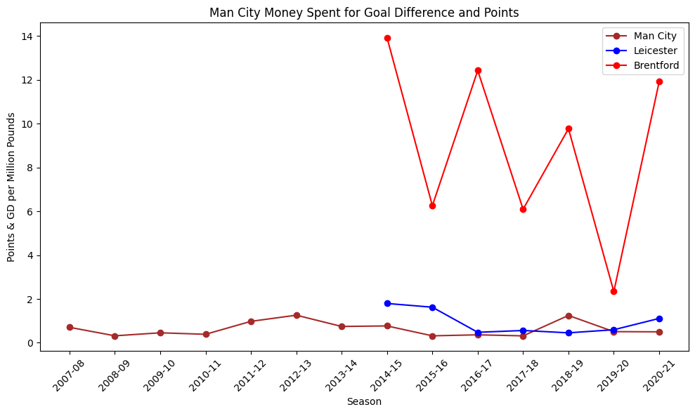

```python
plt.figure(figsize=(10, 6))
plt.plot(mancity['Season'], summary_mc['spending_efficiency'], marker='o', color='brown', label = 'Man City')
plt.plot(leicester['Season'], summary_lc['spending_efficiency'], marker='o', color='blue', label = 'Leicester')
plt.plot(leicester['Season'], brentford_new['spending_efficiency'], marker='o', color='red', label = 'Brentford')



plt.xlabel('Season')
plt.ylabel('Points & GD per Million Pounds')
plt.title('Man City Money Spent for Goal Difference and Points')
plt.legend()
plt.xticks(rotation=45)
plt.tight_layout()

plt.show()
```

As you can see Brentford has a drastically higher efficiency than both of the premier league giants. However is this truly a fair analysis? In order to truly understand whether Brentford's success is something which can be emulated on the big stage such as the Premier League or Champions League, we need to take factors into account.

Being an EFL team at the time, Brentford would obviously have access to a lot smaller amount of assets. In addition the competition level surrounding Brentford in their league would also have a significantly lower payroll than the premier league giants. To analyze this a bit further we need to perform a standardization of our efficiency, in context with the team's respective leagues.

The code provided is focused on calculating the standardized payroll for three football clubs: Manchester City (MC), Leicester City (LC), and Brentford, over specific seasons.

To understand the concept, let's break down the process:

Standardization: This is a statistical method used to account for different scales among different datasets. By standardizing, you're transforming the data to have a mean of zero and a standard deviation of one.

Calculating mean and standard deviation: The code computes the average and standard deviation of the amount spent (value_spent) by Premier League clubs (summary_prem) and Championship clubs (summary_df) for every season.

Creating standardized payroll: For each club (MC, LC, and Brentford):

The code computes the difference between the amount they spent in player transfers and the average spending of all the clubs for the same period. This difference is then divided by the standard deviation for the same period. This process produces a "standardized payroll" for each club. The standardized payroll indicates how much more or less a club spent on transfers compared to an average club, expressed in terms of the number of standard deviations away from the mean. In essence, this analysis provides insight into each club's spending habits relative to the overall spending landscape of their respective leagues. A high positive value indicates that a club has spent much more than the average, while a negative value suggests the opposite. The closer the value is to zero, the closer the club's spending is to the league's average for that year.

```python
standardized_prem = summary_prem.groupby('year')['value_spent'].agg(['mean', 'std']).reset_index()
standardized_prem.rename(columns={'mean': 'mean_value_spent', 'std': 'std_value_spent'}, inplace=True)

# Calculate mean and standard deviation for each unique year in summary_df
standardized_efl = summary_df.groupby('year')['value_spent'].agg(['mean', 'std']).reset_index()
standardized_efl.rename(columns={'mean': 'mean_value_spent', 'std': 'std_value_spent'}, inplace=True)

summary_mc['standardized_payroll'] = (summary_mc['value_spent'].values - standardized_prem['mean_value_spent']).values/standardized_prem['std_value_spent'].values
summary_lc['standardized_payroll'] = (summary_lc['value_spent'].values - standardized_prem['mean_value_spent'].loc[7:13].values)/standardized_prem['std_value_spent'].loc[7:13].values
brentford_new['standardized_payroll'] = (summary_brent['value_spent'].values - standardized_efl['mean_value_spent'].loc[2:8].values)/standardized_efl['std_value_spent'].loc[2:8].values
```

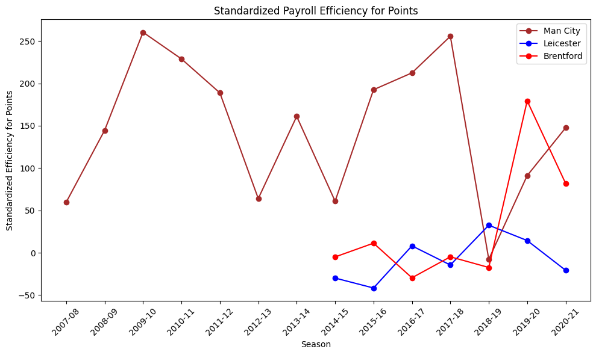

```python
plt.figure(figsize=(10, 6))
plt.plot(mancity['Season'], summary_mc['standardized_payroll'].values * mancity['Pts'].values, marker='o', color='brown', label = 'Man City')
plt.plot(leicester['Season'], summary_lc['standardized_payroll'].values * leicester['Pts'].values, marker='o', color='blue', label = 'Leicester')
plt.plot(leicester['Season'], brentford_new['standardized_payroll'].values * brentford_new['Pts'].values, marker='o', color='red', label = 'Brentford')



plt.xlabel('Season')
plt.ylabel('Standardized Efficiency for Points')
plt.title('Standardized Payroll Efficiency for Points')
plt.legend()
plt.xticks(rotation=45)
plt.tight_layout()

plt.show()
```

## Insight:

Throughout this project, we embarked on a comprehensive analysis of football clubs, with a primary focus on their financial strategies and on-field performances. Here's a conclusion of the insights gained and the broader messages underscored in this tutorial

Financial Efficiency: One of the most striking insights derived from our deep dive was the concept of "spending efficiency." Brentford, in particular, showcased how a club can achieve commendable on-field results, not merely by outspending competitors, but by making astute financial decisions. The money spent per point and goal difference metrics allowed us to measure the tangible on-field impact of each pound spent.

Comparative Analysis with the Elite: By juxtaposing Brentford's performance with top-tier teams like Manchester City and Leicester City, we discerned the variances in spending patterns. This revealed that while clubs in more elite divisions might possess larger financial outlays, efficiency and astute investments are paramount across all tiers.

Standardized Payroll Insights: The standardization process illuminated the relative spending habits of clubs. It underscored that spending more than the average doesn't guarantee success. Clubs like Manchester City, with their vast resources, might naturally skew towards the higher end, but this project emphasized looking beyond raw numbers to truly understand the landscape of financial strategies in football.

Strategic Implications: Beyond just being a financial analysis, the insights drawn can serve as invaluable intelligence for club administrators, fans, and stakeholders. By understanding the balance between expenditure and performance, clubs can make more informed decisions in player transfers and other investments.

Accessibility and Replicability: This tutorial also underscored the power of data-driven analysis in football and, more broadly, in sports. With data becoming increasingly accessible, even amateur analysts like myself can employ such methods to glean insights, make predictions, or just engage more deeply with the sport they love.

In essence, while the beautiful game of football is often celebrated for its moments of magic on the field, behind the scenes, it's as much a game of numbers, strategy, and financial acumen. This project was a testament to that intricate balance between finance and football, and how, when harmonized, they can produce results that are greater than the sum of their parts.